# Loading and preprocessing the data

## Loading and preprocessing the data

**Show any code that is needed to**

**Load the data (i.e. read.csv())**

Reading the file required unzipping it.

```r
tbl <- read.csv(unzip("activity.zip", "activity.csv"), header=TRUE, stringsAsFactors=FALSE)
# Remove the unzipped file after reading
unlink("activity.csv")
```

**Process/transform the data (if necessary) into a format suitable for your analysis**

The date column was converted to Date objects. The 5-minute intervals also need to be mapped to Time objects - but that will happen later, after we've averaged over intervals.

```r
# Make date strings into Date objects
tbl$date <- as.Date(tbl$date, "%Y-%m-%d")
```

## What is mean total number of steps taken per day?

**For this part of the assignment, you can ignore the missing values in the dataset.**

To extract the rows without missing values, the `complete.cases()` function comes in handy.

```r
t_complete <- tbl[complete.cases(tbl),]
```

**Make a histogram of the total number of steps taken each day**

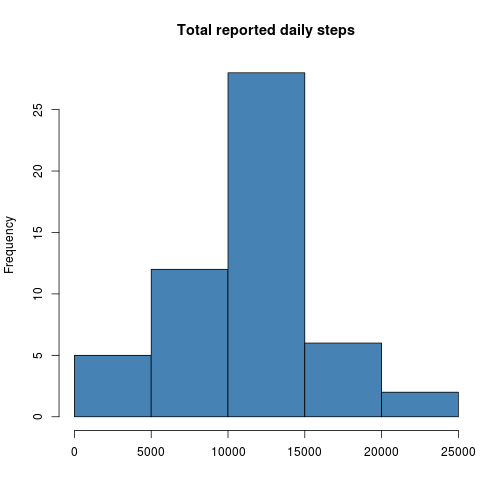

```r
reported_steps_per_day <- aggregate(steps ~ date, t_complete, sum)
hist(reported_steps_per_day$steps, main="Total reported daily steps",
     col="steelblue", xlab="")
```

**Calculate and report the mean and median total number of steps taken per day**

```r
mean(reported_steps_per_day$steps)
```

```
## [1] 10766.19
```

```r
median(reported_steps_per_day$steps)
```

```
## [1] 10765
```

## What is the average daily activity pattern?

**1. Make a time series plot (i.e. type = “l”) of the 5-minute interval (x-axis) and the average number of steps taken, averaged across all days (y-axis)**

After averaging over the intervals, I mapped the intervals to timestamps with an arbitrary date and plotted against those. This makes the curve smoother, because e.g. the gap between 155 (1:55 AM) and 200 (2:00 AM) is 5, not 45.

```r
# Average steps over intervals
mean_steps_per_interval <- aggregate(steps ~ interval, mean, data=t_complete)

# Function maps intervals to timestamps
interval2time <- function(interval,date=tbl$date[1]) {
  hours <- interval %/% 100
  minutes <- interval %% 100
  hm_string <- sprintf("%02i:%02i", hours, minutes)
  as.POSIXct(paste(date,hm_string))
}

# Add a timestamp column using function defined above
mean_steps_per_interval$timestamp <-
  sapply(mean_steps_per_interval$interval, interval2time)
```

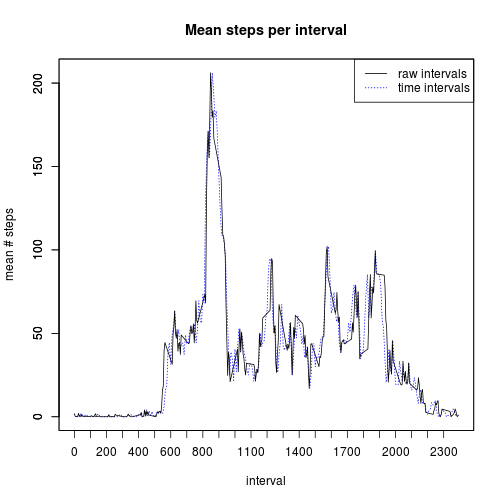

```r
# Plot against time intervals
plot(main="Mean steps per interval",
     x=mean_steps_per_interval$timestamp,
     y=mean_steps_per_interval$steps, type="l",
     col="blue", lty="dotted",
     xlab="",ylab="",xaxt="n")
# but use raw interval labels, to make life easy for graders
axis(1, at=seq(interval2time(0),by="1 hour",length=24),
                  labels=seq(0,2300,by=100))

# Plot against raw intervals
par(new=T)
plot(x=mean_steps_per_interval$interval,
     y=mean_steps_per_interval$steps, type="l",
     ylab="mean # steps", xlab="interval",xaxt="n")

legend("topright",
       c("raw intervals","time intervals"),
       col=c("black","blue"),
       lty=c("solid","dotted"))
```

Note how the curves plotted against raw vs. time intervals differ at crucial inflection points, e.g. between 5 and 6 AM (600), at noon (1200), and between 7 and 8 PM (2000).

Looks as if there's a furious burst of activity between 8 and 9 AM, as people get up and scramble to prepare for the day. Then people are about half as active, more or less, until around 8 PM, when the activity levels taper off.

**2. Which 5-minute interval, on average across all the days in the dataset, contains the maximum number of steps?**

```r
subset(mean_steps_per_interval, steps == max(steps))
```

```
##     interval    steps  timestamp
## 104      835 206.1698 1349094900
```

The interval is 835, containing an average of 206 steps per day. So, as the graph implies, peak activity is at 8:35 AM. Not a good time to ride the Metro!

## Imputing missing values

**Note that there are a number of days/intervals where there are missing values (coded as NA). The presence of missing days may introduce bias into some calculations or summaries of the data.**

**Calculate and report the total number of missing values in the dataset (i.e. the total number of rows with NAs)**

Use complete.cases again, this time negated to find the rows with missing values.

```r
t_missing <- tbl[!complete.cases(tbl),]
nrow(t_missing)
```

```
## [1] 2304
```

There are 2304 rows. Just for kicks, let's see how many NA values there are for each day.

```r
na.count <- function(d) { sum(is.na(tbl[tbl$date == d,][["steps"]])) }
unique_dates <- unique(tbl$date)
t_date2na <- data.frame(date = unique_dates, na_count = sapply(unique_dates, na.count))
length(unique_dates)
```

```
## [1] 61
```

```r
na_days <- subset(t_date2na, na_count > 0)
na_days
```

```
##          date na_count
## 1  2012-10-01      288
## 8  2012-10-08      288
## 32 2012-11-01      288
## 35 2012-11-04      288
## 40 2012-11-09      288
## 41 2012-11-10      288
## 45 2012-11-14      288
## 61 2012-11-30      288
```

```r
nrow(na_days)
```

```
## [1] 8
```

So 2304 rows = 8 days x 24 hours x 12 five-minute intervals per hour. Of the 61 days total, there are eight days with all values missing, and no values missing elsewhere. Good to know!

**Devise a strategy for filling in all of the missing values in the dataset. The strategy does not need to be sophisticated. For example, you could use the mean/median for that day, or the mean for that 5-minute interval, etc.**

OK, I'll use the mean for that 5-minute interval, since it's been calculated already.

**Create a new dataset that is equal to the original dataset but with the missing data filled in.**

```r
# Fill in missing values from mean_steps_per_interval
t_missing$steps <- sapply(t_missing$interval, function(i) {
  as.numeric(subset(mean_steps_per_interval, interval == i, steps))
})

# Combine complete cases and now-no-longer-incomplete cases
t_imputed <- rbind(t_complete,t_missing)
```

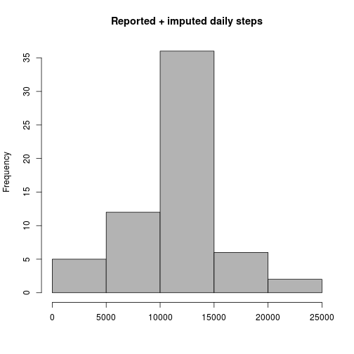

```r
imputed_steps_per_day <- aggregate(steps ~ date, sum, data=t_imputed)

hist(imputed_steps_per_day$steps, main="Reported + imputed daily steps",
     col="gray70", xlab="")
```

The graph below compares the reported and imputed totals: exactly the same, except for the eight days with missing values. Originally, there were 10 days containing the mean number of steps. Now there are 18.

```r
# Set up a data frame comparing reported to imputed totals.
library(reshape2)
# Throw both totals into a list with appropriate labels...
totals <- list(reported=reported_steps_per_day,imputed=imputed_steps_per_day)
# ...and melt it down, so that the labels become their own column.
comparison <- melt(totals, id.vars=c("date","steps"))
names(comparison) <- c("date", "steps", "status")
comparison$status <- factor(comparison$status, levels=c("reported", "imputed"))
```

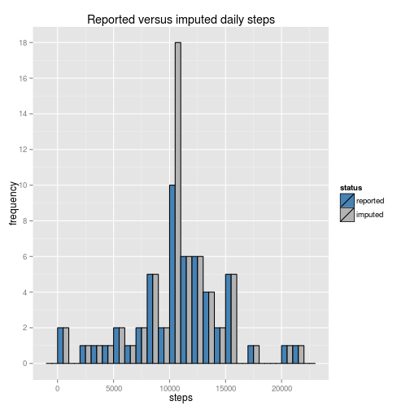

```r
library(ggplot2)
ggplot(comparison,aes(x=steps,fill=status)) +
  ggtitle("Reported versus imputed daily steps") +
  # position "dodge" = side by side
  geom_histogram(binwidth=1000,position="dodge",colour="black") +
  # less ugly than the default colors
  scale_fill_manual(values=c("steelblue","gray70")) +
  scale_y_continuous(name="frequency",breaks=seq(0,20,by=2))
```

**Calculate and report the mean and median total number of steps taken per day.**

```r
mean(imputed_steps_per_day$steps)
```

```
## [1] 10766.19
```

```r
median(imputed_steps_per_day$steps)
```

```
## [1] 10766.19
```

**Do these values differ from the estimates from the first part of the assignment?**

The mean is the same, but the median has increased slightly.

```r
mean(imputed_steps_per_day$steps) - mean(reported_steps_per_day$steps)
```

```
## [1] 0
```

```r
median(imputed_steps_per_day$steps) - median(reported_steps_per_day$steps)
```

```
## [1] 1.188679
```

**What is the impact of imputing missing data on the estimates of the total daily number of steps?**

The median is now equal to the mean, because of the extra imputed days with exactly the mean number of steps. This reduces the variation in the data set; see the density curves below.

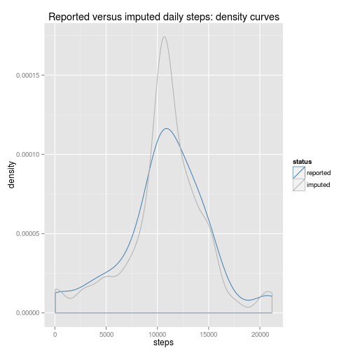

```r
ggplot(comparison, aes(x=steps,colour=status)) + geom_density() +
  ggtitle("Reported versus imputed daily steps: density curves") +
  scale_color_manual(values=c("steelblue","gray70"))
```

This reduced variability may affect estimates like the one in the next section.

## Are there differences in activity patterns between weekdays and weekends?

**For this part the weekdays() function may be of some help here. Use the dataset with the filled-in missing values for this part.**

**Create a new factor variable in the dataset with two levels – “weekday” and “weekend” indicating whether a given date is a weekday or weekend day.**

```r
# Define a function mapping date to weekend/weekday
day_type <- function(date) {
  if (weekdays(date) %in% c("Saturday","Sunday")) "weekend" else "weekday"
}

# Add a column using this function
t_imputed$day_type <- as.factor(sapply(t_imputed$date, day_type))
```

Note that using the imputed values could obscure the patterns we're looking for, since the averages were computed over all days. The eight days with missing values were a mix of weekdays and weekends:

```r
summary(as.factor(sapply(subset(t_date2na, na_count > 0)[["date"]], day_type)))
```

```
## weekday weekend
##       6       2
```

**Make a panel plot containing a time series plot (i.e. type = “l”) of the 5-minute interval (x-axis) and the average number of steps taken, averaged across all weekday days or weekend days (y-axis).**

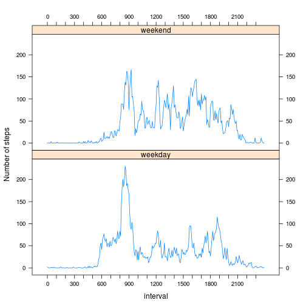

```r
mean_steps2 <- aggregate(steps ~ interval + day_type, mean, data=t_imputed)

# Again, we add a timestamp column mapping intervals to timestamps
mean_steps2$timestamp <- sapply(mean_steps2$interval, interval2time)

library(lattice)

# Plot against timestamps...
xticks <- seq(interval2time(0), by="1 hour",length=24)
# but label the x-axis by intervals so as not to confuse the grader
xlabels <- seq(0,2400,by=300)
xlabels <- as.vector(rbind(xlabels,"",""))

# Do the plot
xyplot( steps ~ timestamp | day_type, data=mean_steps2, type="l",
        xlab="interval", ylab="Number of steps", layout=c(1,2),
        scales=list(alternating=3, x=list(at=xticks, labels=xlabels)) )
```